# Robotruck

## TOC

- Ideas
- Donkey Car

## Ideas

### Swarm

#### Daimler Schneepflug

### Carerra challenge

- externe Infrastruktur
- fester Fahrweg
- suche nach höchstmöglicher Geschwindigkeit

### Farmrobot

### Uses Cases Backwards

#### Enno Lenze Sicherheitstraining

- https://ennolenze.de/eine-woche-zu-gast-beim-kriegsprofiteur/2448/
- J-Turn
  - [Reverse 180 or J-Turn](https://www.youtube.com/watch?v=EWH-yTzLs7k)

[figure not shown]

- [US Army Evasive Driving Training Video (1988)]

#### LKW Rangieren

- [Lafette rangieren und Lkw aufbrücken](https://www.youtube.com/watch?v=OceO39XHK9I)
- [Fahrschule LKW Rangieren mit Gliederzügen](https://www.youtube.com/watch?v=2htG14JY_0s)

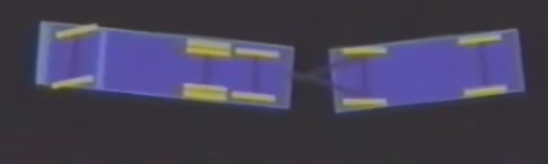

- [Beim Aufbrücken zusehen in Echtzeit](https://www.youtube.com/watch?v=GR2EItjbVgc)

[figure not shown]

## Donkeycar

### Resources

- https://robocaresslingen.github.io/BookDownDocu/
- https://github.com/RoboCarEsslingen/BookDownDocu

## Getting on the Road

### donkeypi

#### Hardware

- [Raspberry Pi](https://www.reichelt.de/raspberry-pi-3-b-4x-1-2-ghz-1-gb-ram-wlan-bt-raspberry-pi-3-p164977.html?r=1)

##### PWM HAT

- [PWM SERVO HAT](https://www.reichelt.de/raspberry-pi-servo-hat-16-kanal-pwm-rpi-servo-hat-p235533.html?)
- Raspi Treiber?

###### 01

###### 02 PWM/Servo HAT & Bonnet for Raspberr

[Adafruit 16-Channel PWM/Servo HAT & Bonnet for Raspberry Pi16 channels of servo-bust](https://learn.adafruit.com/adafruit-16-channel-pwm-servo-hat-for-raspberry-pi/overview)

[Adafruit 16 Channel Servo Driver with Raspberry Pi](https://cdn-learn.adafruit.com/downloads/pdf/adafruit-16-channel-servo-driver-with-raspberry-pi.pdf)

[figure not shown]

###### 03 Adafruit 16-Channel PWM / Servo Bonnet for Raspberry Pi

- https://www.adafruit.com/product/3416

[figure not shown]

###### Configuring Your Pi for I2C

- https://learn.adafruit.com/adafruits-raspberry-pi-lesson-4-gpio-setup/configuring-i2c

##### Wii Controller

[WiiU controller](https://www.amazon.de/dp/B06XSB2TXQ/ref=pe_3044161_185740101_TE_item)  
* https://robocaresslingen.github.io/BookDownDocu/donkeycar-software-analysis.html#assignment-of-wiiu-controller-sticks-to-action * http://docs.donkeycar.com/parts/controllers/#physical-joystick-controller * https://github.com/autorope/donkeypart_bluetooth_game_controller * https://github.com/aueb/autonomousdriving/wiki/Consoles * https://github.com/the-raspberry-pi-guy/Wiimote * API for Unity https://github.com/Flafla2/Unity-Wiimote

###### Raspikompatible Bluetooth Adapter

- https://elinux.org/RPi_VerifiedPeripherals#USB_Bluetooth_adapters
- https://elinux.org/RPi_USB_Bluetooth_adapters

##### DC/DC Converter

DC/DC converter for raspi

[Pimoroni Wide Input SHIM](https://shop.pimoroni.com/products/wide-input-shim?variant=2168104321034)

###### Features

```
Super-small SHIM-format board
0.8mm thick PCB
Can be used with HATs and pHATs
3.5mm outer diameter barrel jack connector (centre positive)
Adapter cables included
TPS630701 buck-boost converter chip (data sheet)
  * https://cdn.shopify.com/s/files/1/0174/1800/files/tps63070.pdf?4184684033596395658
5V / up to 2A output
3-16V input
Reverse voltage protection
EN (enable) pin to switch off output voltage (pull to ground)
Requires soldering
```

###### Usage

You can supply a range input voltages to Wide Input SHIM, either through the centre positive 3.5mm outer diameter barrel jack connector, or through the two broken-out + and - pins on the SHIM.

The board will provide 5V/2A output (through the GPIO to the Pi) at input voltages of 5V to 16V. Current drops to 1.5A at 4V, and 1A at 3V.

#### US Sensoren

#### Lightning

##### Frontlight

##### Rearlight

### Raspi@Car

#### Truck

#### Raspi 3

- hostname: donkeypi
- User: pi
- Pw wie üblich
- in funkstation2
- 192.168.178.122

@shack

b8:27:eb:9c:27:34 10.42.22.180 donkeypi Sat Feb 23 2019 13:21:29 (CET)

##### wpa.conf

- /etc/wpa_supplicant

#### Image Download

- Raspi P3 Image 2.5 https://drive.google.com/file/d/1vr4nEXLEh4xByKAXik8KhK3o-XWgo2fQ/view

#### Raspi Zero

##### Image Download

- Raspi Zero Image 2.5 https://drive.google.com/file/d/1otqNRBs1kqNJYocCp4kbMjcRKWE2zW7A/view

#### setup

- https://docs.donkeycar.com/guide/install_software/#get-the-raspberry-pi-working
- with Virtenv
  - https://medium.com/@ronm333/installing-donkeycar-on-the-raspberry-pi-b3eb72a474a8

#### Calibrate the Car

- - [Calibrate your car](http://docs.donkeycar.com/guide/calibrate/)

#### Install smbus and i2c-tools

```bash
sudo apt-get install python-smbus
sudo apt-get install i2c-tools
```

Check

```bash
sudo i2cdetect -y 1
```

```bash
pip install donkeycar[pi]
#test that you are using the most recent version (found in __init__ file)
python -c "import donkeycar as dk; print(dk.__version__)"
```

### carcam1

- Hostname: carcam1
- B8:27:EB:A5:3B:FF, dhcpcd-6.11.5:Linux-4.14.78+:armv6l:BCM2835

user pi pw kurz

carcam1 funkstation2 192.168.178.112

[Raspbery Pi camera](https://www.amazon.de/dp/B00N1YJKFS/ref=pe_3044161_189395811_TE_dp_1)

- RaspiZero
- https://medium.com/home-wireless/headless-streaming-video-with-the-raspberry-pi-zero-w-and-raspberry-pi-camera-38bef1968e1

##### raspi shell zugang via Bluetooth

- ct 201901

##### Install mjpg-streamer

```bash
sudo apt-get install libjpeg8-dev imagemagick libv4l-dev uvcdynctrl
sudo apt-get install git cmake
```

###### get the latest code

```bash
git clone https://github.com/jacksonliam/mjpg-streamer.git
cd mjpg-streamer/mjpg-streamer-experimental
make USE_LIBV4L2=true clean all
```

- note this will spew a few errors. ignore them
- you need to be in the video group

```bash
sudo usermod -aG video myUserName
```

[Optional] Install the Broadcom V4L2 driver and run

```bash
sudo modprobe bcm2835-v4l2
./mjpg_streamer -i "input_uvc.so -d /dev/video0 -r 1640x1232" -o "output_http.so -w ./www"
```

Here I’m using half-resolution. Full resolution seemed to run out of memory. But… this is real-time and good enough resolution for my application. If I need higher resolution I can duck the frame rate or capture stills. Note that the Broadcom driver needs to be part of the OS and this only installs it for the session. To install it as part of startup, add the module name to /etc/modules. Use the custom raspberry pi camera driver

The nice thing about this build is that there’s a driver for the raspberry pi. This does not require a v4l2 driver. You can simply run it like this:

```bash
./mjpg_streamer -i "input_raspicam.so -x 1920 -y 1080" -o 'output_http.so -w ./www"
```

Or, you can do 2MP at the right aspect ratio:

```bash
./mjpg_streamer -i "input_raspicam.so -x 1640 -y 1232" -o "output_http.so -w ./www"
```

Trying to stream video at the full 8MP caused a kernel panic. I was able to stream at 1fps on my Zero W, but the readout said it was capturing at 1.5fps so there wasn’t much margin. I used this line:

```bash
./mjpg_streamer -i "input_raspicam.so -x 3280 -y 2464 -fps 1" -o "output_http.so -w ./www"
```

Open a web browser and browse to http://myraspberrypi:8080 and you should see the mjpg-streamer user interface and be able to stream.

##### Install UV4L and WebRTC

### router

### on PC

### Linux

#### Github

#### Python

## 20190223

### Rainer

- link Github
- makemovie
  - Kann man in das Video Geschwindigkeit und Lenkwinkel einblenden
  - ffmpeg second Cam
- zweites Video -> Uwe
- Tom Kremer
- repo of the simulator
- ROS -> Blogeintrag